# Sistema de Recomendação Para Rede de Varejo Usando Market Basket Analysis

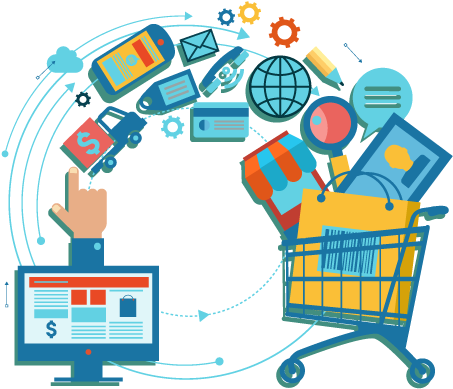

## Sobre

Projeto com Feedback nº 10 do curso Business Analytics da Formação Cientista de Dados da Data Science Academy.

A partir da análise do dataset “The Instacart Online Grocery Shopping Dataset 2017” - quem contém mais de 3 milhões de pedidos de mais de 200 mil usuários - foi feito um trabalho de análise de dados com o objetivo de prever quais produtos adquiridos anteriormente estarão no próximo pedido de um usuário.

Acesso para o dataset: [instacart](https://www.kaggle.com/c/instacart-market-basket-analysis)

Artigo sobre o case: [artigo](https://tech.instacart.com/3-million-instacart-orders-open-sourced-d40d29ead6f2)

### Baixando pacotes necessários

```r
library(data.table)
library(dplyr)
library(arules)
library(ggplot2)
library(gridExtra)
library(wordcloud)
library(xgboost)
library(naniar)
library(caret)
library(RColorBrewer)
library(kableExtra)
```

### Leitura dos datasets e Dicionários de Dados

Tabela de Pedidos (tabela Fato) - 3.4 milhões de linhas

```r
pedidos <- fread("datasets/orders.csv")

orders_dic <- data.frame(Variável = c("ID Pedido", "ID Comprador", 'Classificação do pedido',
                                      "Número do Pedido", "Dia do Pedido", "Hora do Pedido",
                                      "Dias Desde o Último Pedido"),
                         Descrição = c("identificação do pedido", "identificação do comprador",
                         "classificação de pedido: prior = pedido comum/ train = pedidos reservados para dataset de treino/ test = pedidos reservados para dataset de teste",
                         "nº do pedido realizado pelo consumidor",
                         "dia da semana que o pedido foi realizado pelo consumidor",
                         "hora do dia que o pedido foi realizado",
                         "dias desde o último pedido deste consumidor"))

orders_dic  %>%
    kbl() %>% kable_paper('striped',full_width = F) %>%
    row_spec(0, bold = T)
```

| Variável | Descrição |
| --- | --- |
| ID Pedido | identificação do pedido |
| ID Comprador | identificação do comprador |
| Classificação do pedido | classificação de pedido: prior = pedido comum/ train = pedidos reservados para dataset de treino/ test = pedidos reservados para dataset de teste |
| Número do Pedido | nº do pedido realizado pelo consumidor |
| Dia do Pedido | dia da semana que o pedido foi realizado pelo consumidor |
| Hora do Pedido | hora do dia que o pedido foi realizado |
| Dias Desde o Último Pedido | dias desde o último pedido deste consumidor |

Tabela de Produtos (tabela Dimensão) - 50 mil linhas

```r
produtos <- fread("datasets/products.csv")

produtos_dic <- data.frame(Variável = c("ID Produto", "Nome do Produto",
                                        "ID do Corredor", "ID do Departamento"),
                           Descrição = c("identificação do produto", "nome do produto",
                                         "identificação do corredor que o produto está localizado.",
                                         "identificação do departamento que o produto pertence."))

produtos_dic %>%
    kbl() %>% kable_paper('striped',full_width = F) %>%
    row_spec(0, bold = T)
```

| Variável | Descrição |
| --- | --- |
| ID Produto | identificação do produto |
| Nome do Produto | nome do produto |
| ID do Corredor | identificação do corredor que o produto está localizado. |
| ID do Departamento | identificação do departamento que o produto pertence. |

Tabela de Corredores (tabela Dimensão) - 134 linhas

```r
corredores <- fread("datasets/aisles.csv")

corredores_dic <- data.frame(Variável = c("ID Corredor", "Nome do Corredor"),
                             Descrição = c("identificação dos corredores do mercado.",
                                           "nomes dos corredores do mercado."))

corredores_dic %>%
    kbl() %>% kable_paper('striped',full_width = F) %>%
    row_spec(0, bold = T)
```

| Variável | Descrição |
| --- | --- |
| ID Corredor | identificação dos corredores do mercado. |
| Nome do Corredor | nomes dos corredores do mercado. |

Tabela de Departamentos (tabela Dimensão) - 21 linhas

```r
departamentos <- fread("datasets/departments.csv")

departamentos_dic <- data.frame(Variável = c("ID Departamento", "Nome do Departamento"),
                                Descrição = c("identificação dos departamentos do mercado.",
                                              "nome dos departamentos do mercado."))

departamentos_dic %>%
    kbl() %>% kable_paper('striped',full_width = F) %>%
    row_spec(0, bold = T)
```

| Variável | Descrição |
| --- | --- |
| ID Departamento | identificação dos departamentos do mercado. |
| Nome do Departamento | nome dos departamentos do mercado. |

Tabelas de Especificidades de Pedidos - >= 30 milhões de linhas

Carregando apenas ’order_products__train.csv’ para aplicar a regra de associação com ele por conta de memória

```r
pedidos_esp <- fread("datasets/order_products__train.csv")

pedidos_esp_dic <- data.frame(Variável = c("ID Pedido", "ID Produto",
                                           "Ordem de Adição ao Carrinho", "Produto Repetido?"),
                              Descrição = c("identificação do pedido", "identificação do produto",
                                            "ordem que o item foi adicionado ao carrinho em determinada compra",
                                            "informa se o produto está sendo pedido novamente (1) ou não (0)."))

pedidos_esp_dic %>%
    kbl() %>% kable_paper('striped',full_width = F) %>%
    row_spec(0, bold = T)
```

| Variável | Descrição |
| --- | --- |
| ID Pedido | identificação do pedido |
| ID Produto | identificação do produto |
| Ordem de Adição ao Carrinho | ordem que o item foi adicionado ao carrinho em determinada compra |
| Produto Repetido? | informa se o produto está sendo pedido novamente (1) ou não (0). |

### Tratamento dos datasets

Fazendo cópia dos datasets para partes 1 e 2 (boa prática caso seja necessário voltar ao dataset original por algum motivo)

```r
df_pedidos <- pedidos
df_pedidos2 <- pedidos
```

**Valores NA**

```r
na_count <- as.data.frame(sapply(df_pedidos, function(y) sum(length(which(is.na(y))))))
names(na_count) <- "Qtd. NAs"

na_count %>%
    kbl() %>% kable_paper('striped',full_width = F) %>%
    row_spec(0, bold = T)
```

|  | Qtd. NAs |
| --- | --- |
| order_id | 0 |
| user_id | 0 |
| eval_set | 0 |
| order_number | 0 |
| order_dow | 0 |
| order_hour_of_day | 0 |
| days_since_prior_order | 206209 |

Observamos que existe um número considerável de NAs, porém,apenas na coluna referente a quantidade de dias desde a última compra de determinado consumidor. Para tratar esses valores NAs, vamos substituir esses NAs pelo número 0, tendo em vista que se não houve intervalo de dias entre as compras, podemos aplicar o número zero para representar esta informação.

```r
df_pedidos$days_since_prior_order[is.na(df_pedidos$days_since_prior_order)] <- 0
df_pedidos2$days_since_prior_order[is.na(df_pedidos2$days_since_prior_order)] <- 0
```

### Parte 1

Análise Exploratória com identificação de itens mais pedidos em conjunto (duplas) Foco na exploração do dataset com pacote dlpyr e depois aplicação dos algoritmos de MBA (Market Basket Analysis) ECLAT e APRIORI.

**Feature Engineering**

Criando nova coluna (dia_da_semana) com nome do dia da semana para posterior análise exploratória e a transformando em fator

```r
df_pedidos$dia_da_semana[df_pedidos$order_dow == 0] <- "Domingo"
df_pedidos$dia_da_semana[df_pedidos$order_dow == 1] <- "Segunda"
df_pedidos$dia_da_semana[df_pedidos$order_dow == 2] <- "Terça"
df_pedidos$dia_da_semana[df_pedidos$order_dow == 3] <- "Quarta"
df_pedidos$dia_da_semana[df_pedidos$order_dow == 4] <- "Quinta"
df_pedidos$dia_da_semana[df_pedidos$order_dow == 5] <- "Sexta"
df_pedidos$dia_da_semana[df_pedidos$order_dow == 6] <- "Sábado"

df_pedidos$dia_da_semana <- factor(df_pedidos$dia_da_semana,
                                   levels = c("Domingo", "Segunda", "Terça", "Quarta", "Quinta", "Sexta", "Sábado"))
```

Periodicidade de Compras

```r
df_pedidos$periodicidade[df_pedidos$days_since_prior_order == 0] <- "baixa"
df_pedidos$periodicidade[df_pedidos$days_since_prior_order > 15] <- "alta"
df_pedidos$periodicidade[is.na(df_pedidos$periodicidade)] <- "média"
```

**Tratamento de dataset pedidos_esp para os algoritmos de MBA**

O dataset pedidos_esp será combinado com demais tabelas dimensão e será utilizado, além de em alguns momentos para análise exploratória, prioritariamente para utilização no ECLAT e no APRIORI

```r
pedidos_esp_analise <- pedidos_esp %>%
    left_join(produtos, by = "product_id")

df_modelo <- pedidos_esp_analise %>%
    group_by(order_id) %>%
    summarise(produtos = as.vector(list(product_name)))
```

**Análise Exploratória**

Para construção dos gráficos usarei a escala Greys do pacote RColorBrewer, com o acréscimo de uma cor para ter uma paleta com 10 cores

```r
cores <- c(brewer.pal(n = 9, "Greys"),"#999999")
```

Gráfico de quantidade de pedidos por hora do dia

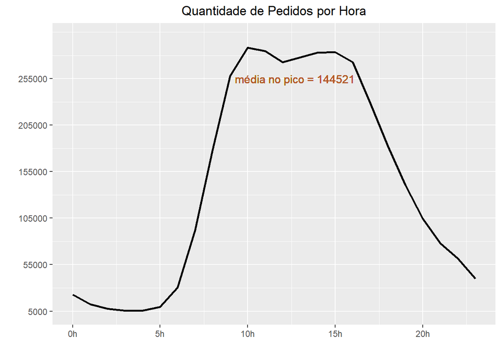

```r
quadro1 <- df_pedidos %>%
    group_by(order_hour_of_day) %>%
    summarise(contagem = n())

media1 <- round(mean(c(quadro1$contagem[quadro1$order_hour_of_day <= 15],
                quadro1$contagem[quadro1$order_hour_of_day <= 15])),0)

df_pedidos %>%
    group_by(order_hour_of_day) %>%
    summarise(contagem = n()) %>%
    ggplot(aes(x = order_hour_of_day, y = contagem, group = 1)) + geom_line(size = 1) +
    geom_text(aes(label = paste("média no pico =", media1), x = 12.7, y = 255000), colour = "#B15928", size = 4) +
    labs(title ='Quantidade de Pedidos por Hora', x = '', y = '') +
    scale_x_continuous(labels = paste0(seq(0, 25, 5), 'h')) +
    scale_y_continuous(limits = c(5000, 300000), breaks = seq(5000, 300000, 50000)) +
    theme(plot.title = element_text(hjust = 0.5))
```

Percebemos um pico de pedidos entre 10h e 15h, que se mantém estável e inicia queda por volta das 16h. Vale atentar para reposição de produtos, atendimento e instabilidades do sistema neste período de tempo.

Gráfico de Periodicidade

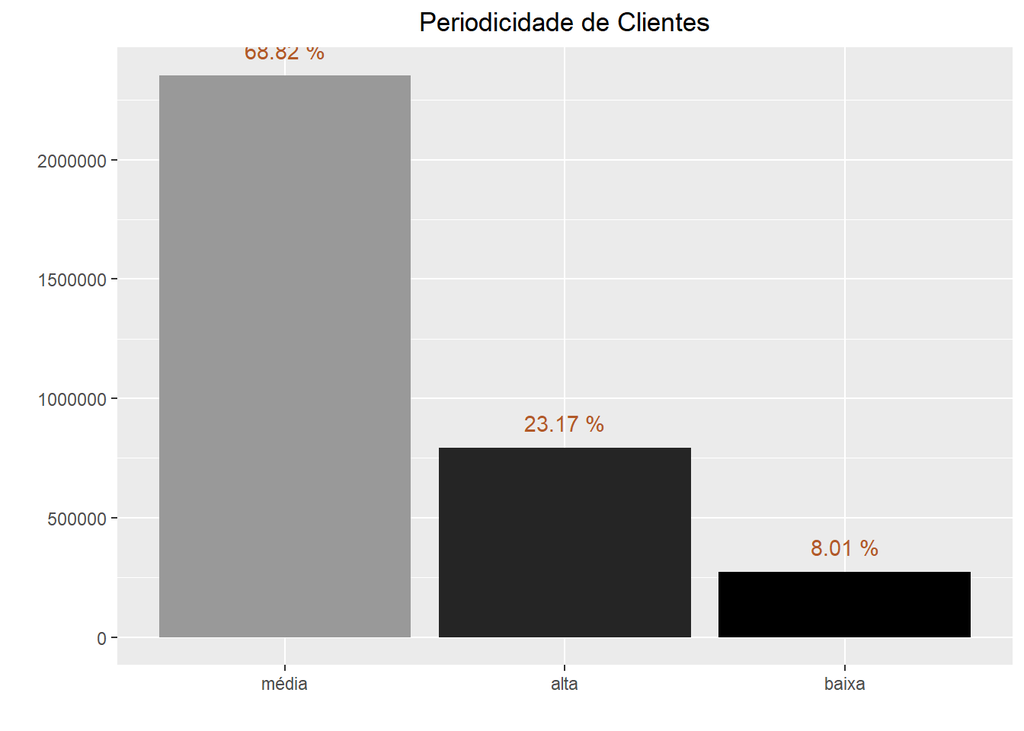

```r
df_pedidos %>%
    group_by(periodicidade) %>%
    summarise(contagem = n()) %>%
    mutate(percentual = paste(round(contagem / sum(contagem) * 100,2), "%")) %>%
    ggplot(aes(x = reorder(periodicidade, - contagem), y = contagem)) + geom_col(aes(fill = periodicidade)) +
    geom_text(aes(label = percentual), vjust = -1, colour = "#B15928") +
    labs(title ='Periodicidade de Clientes', x = '', y = '') +
    theme(plot.title = element_text(hjust = 0.5), legend.position="none") +
    scale_fill_manual(values = cores[8:10])
```

Gráfico de Corredores e Produtos mais frequentes

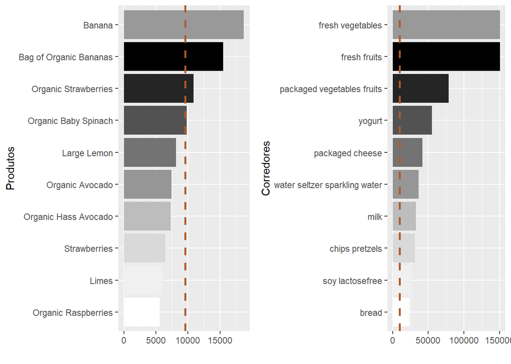

```r
quadro_graf1 <- pedidos_esp %>%
    left_join(produtos, by = "product_id") %>%
    group_by(product_name) %>%
    summarise(contagem = n()) %>%
    mutate(product_name = reorder(product_name, contagem)) %>%
    slice_max(product_name, n = 10)

media_graf1 <- mean(quadro_graf1$contagem)

graf1 <- pedidos_esp %>%
    left_join(produtos, by = "product_id") %>%
    group_by(product_name) %>%
    summarise(contagem = n()) %>%
    mutate(product_name = reorder(product_name, contagem)) %>%
    slice_max(product_name, n = 10) %>%
    ggplot(aes(x = product_name, y = contagem)) + geom_col(aes(fill = product_name)) +
    geom_hline(yintercept = media_graf1, linetype = "dashed", size = 1, colour = "#B15928") +
    coord_flip() + labs(x = 'Produtos', y = '') +
    theme(legend.position="none") +
    scale_fill_manual(values = cores)

quadro_graf2 <- pedidos_esp %>%
    left_join(produtos, by = "product_id") %>%
    left_join(corredores, by = "aisle_id") %>%
    group_by(aisle) %>%
    summarise(contagem = n()) %>%
    mutate(aisle = reorder(aisle, contagem)) %>%
    slice_max(aisle, n = 10)

media_graf2 <- mean(quadro_graf1$contagem)

graf2 <- pedidos_esp %>%
    left_join(produtos, by = "product_id") %>%
    left_join(corredores, by = "aisle_id") %>%
    group_by(aisle) %>%
    summarise(contagem = n()) %>%
    mutate(aisle = reorder(aisle, contagem)) %>%
    slice_max(aisle, n = 10) %>%
    ggplot(aes(x = aisle, y = contagem)) + geom_col(aes(fill = aisle)) + coord_flip() +
    geom_hline(yintercept = media_graf2, linetype = "dashed", colour = "#B15928", size = 1) +
    labs(x = 'Corredores', y = '') +
    theme(legend.position="none") +
    scale_fill_manual(values = cores)

grid.arrange(graf1, graf2, ncol = 2)
```

Gráfico de Qtd de vendas por dia

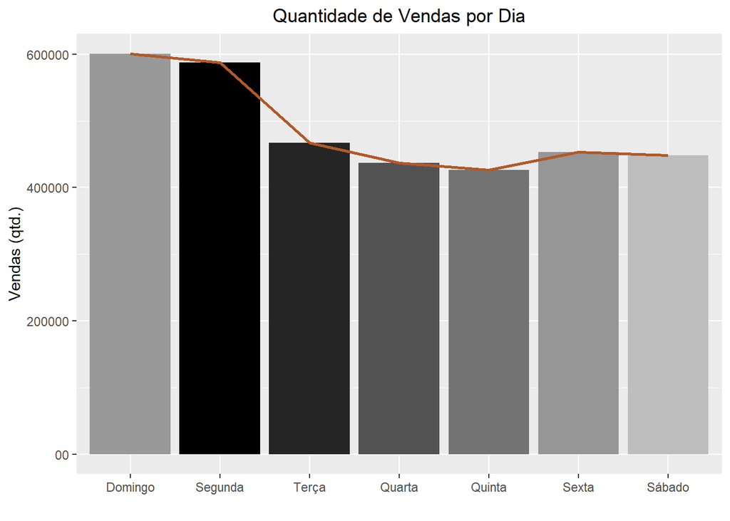

```r
quadro2 <- df_pedidos %>%
    group_by(dia_da_semana) %>%
    summarise(contagem = n() / 10)

#min(quadro2$contagem)
#max(quadro2$contagem)

df_pedidos %>%
    group_by(dia_da_semana) %>%
    summarise(contagem = n()/10) %>%
    ggplot(aes(x = dia_da_semana, y = contagem)) + geom_col(aes(fill = dia_da_semana)) +
    geom_line(aes(y = contagem, group = 1), size = 1, colour = "#B15928") +
    labs(title ='Quantidade de Vendas por Dia', x = '', y = 'Vendas (qtd.)') +
    scale_y_continuous(name = "Vendas (qtd.)", label = paste0(seq(0, 60100, 20000), '0'),
                       limits = c(0, 60100), breaks = seq(0, 60100, 20000)) +
    theme(plot.title = element_text(hjust = 0.5), legend.position="none") +
    scale_fill_manual(values = cores[10:4])
```

De acordo com os dados deste dataset, há mais pedidos no domingo e na segunda, enquanto nos próximos dias parece haver uma média constante, retomando levamente o crescimento na sexta.

Mapa de palavras

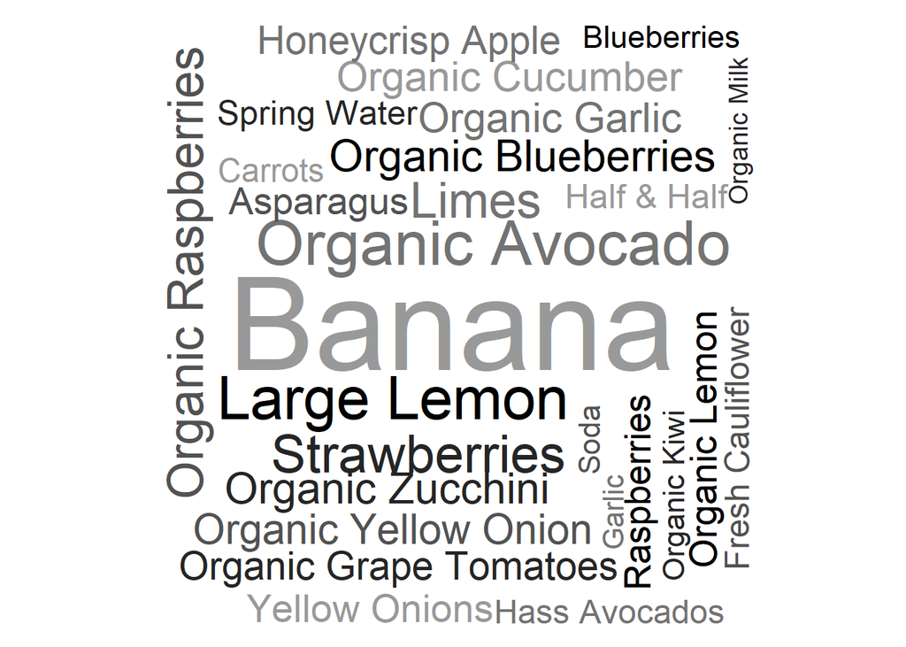

```r
df_wc <- pedidos_esp %>%
    left_join(produtos, by = "product_id") %>%
    group_by(product_name) %>%
    summarise(soma = sum(reordered)) %>%
    mutate(product_name = reorder(product_name, soma)) %>%
    slice_max(product_name, n = 200)

wordcloud(words = df_wc$product_name, freq = df_wc$soma, scale = c(6,1),
          random.order = FALSE, random.color = FALSE , rot.per = 0.35,
          ordered.colors = TRUE, colors = rep(cores[10:6], 40))
```

Tabela de produtos que mais foram adicionados primeiro ao carrinho

```r
prod_table <- pedidos_esp %>%
    filter(add_to_cart_order == 1) %>%
    left_join(produtos, by = "product_id") %>%
    group_by(product_name) %>%
    summarise(contagem = n()) %>%
    mutate(product_name = reorder(product_name, contagem)) %>%
    slice_max(product_name, n = 20)

prod_table %>%
    rename("Produto" = "product_name", "Frequência" = "contagem") %>%
    kbl() %>% kable_paper('striped',full_width = F) %>%
    row_spec(0, bold = T)
```

| Produto | Frequência |
| --- | --- |
| Banana | 4605 |
| Bag of Organic Bananas | 3889 |
| Organic Whole Milk | 1144 |
| Organic Avocado | 995 |
| Organic Strawberries | 900 |
| Organic Baby Spinach | 869 |
| Organic Hass Avocado | 797 |
| Spring Water | 730 |
| Strawberries | 707 |
| Sparkling Water Grapefruit | 647 |
| Large Lemon | 575 |
| Soda | 557 |
| Organic Raspberries | 557 |
| Hass Avocados | 452 |
| Raspberries | 435 |
| Large Alfresco Eggs | 405 |
| Organic Half & Half | 397 |
| Organic Blueberries | 393 |
| Organic Banana | 384 |
| Unsweetened Almondmilk | 378 |

Nesta tabela observamos, também, a presença de alimentos específicos e também perecíveis, ou seja, de pronto consumo. Isso pode significar que o consumidor, alem de se preocupar com o preparo de suas refeições e, ao realizar as compras, pretende elaborar seus pratos de maneira imediata.

Aplicação dos Algoritmos de MBA (ECLAT e APRIORI)

Join com dataset de produtos para coletar nome de cada produto

```r
df_modelo <- pedidos_esp %>%
    left_join(produtos, by = "product_id")
```

**Algoritmos de Regra de Associação e seus detalhes** O que é um algoritmo de regra de associação? * Suporte = conta quantas vezes o item aparece na relação de proutos * Confiança = é o cálculo da probabilidade da ocorrência de uma dupla de produtos * Elevação = é a medida que informa quanto um item X aumenta a possibilidade de ter o item Y no mesmo pedido. Para elevações > 1, sabemos que ter X no pedido leva também a pedir Y, já elevações < 1 nos informa que pedir X não significa aumento de chances de pedir também Y, mesmo que a confiança entre os 2 itens esteja alta.

Transformação Estes algoritmos esperam receber uma lista de listas para cada transação (pedido), então, realizarei um agrupamento de acordo com o id do pedido, apresentando todos os itens comprados em cada pedido:

```r
df_modelo <- df_modelo %>%
    group_by(order_id) %>%
    summarize(produtos = as.vector(list(product_name)))
```

Transformando o dataset em um objeto do tipo transactions, formando uma matriz esparsa e entendendo o resultado:

```r
transacoes <- as(df_modelo$produtos, "transactions")
summary(transacoes)
```

```
## transactions as itemMatrix in sparse format with
##  131209 rows (elements/itemsets/transactions) and
##  39123 columns (items) and a density of 0.0002697329
##
## most frequent items:
##                 Banana Bag of Organic Bananas   Organic Strawberries
##                  18726                  15480                  10894
##   Organic Baby Spinach            Large Lemon                (Other)
##                   9784                   8135                1321598
##
## element (itemset/transaction) length distribution:
## sizes
##    1    2    3    4    5    6    7    8    9   10   11   12   13   14   15   16
## 6845 7368 8033 8218 8895 8708 8541 7983 7217 6553 6034 5383 4843 4394 3831 3522
##   17   18   19   20   21   22   23   24   25   26   27   28   29   30   31   32
## 3108 2719 2473 2102 1857 1681 1462 1292 1079  986  860  679  634  553  446  403
##   33   34   35   36   37   38   39   40   41   42   43   44   45   46   47   48
##  346  315  280  210  193  178  142   99   90   88   75   79   64   48   49   32
##   49   50   51   52   53   54   55   56   57   58   59   60   61   62   63   64
##   26   31   24   23   18   15   12   10    6    5    4    8    3    3    5    4
##   65   66   67   68   70   72   74   75   76   77   80
##    3    2    1    2    4    2    2    1    2    1    2
##
##    Min. 1st Qu.  Median    Mean 3rd Qu.    Max.
##    1.00    5.00    9.00   10.55   14.00   80.00
##
## includes extended item information - examples:
##                         labels
## 1            #2 Coffee Filters
## 2 #2 Cone White Coffee Filters
## 3        #2 Mechanical Pencils
```

Plot da distribuição de frequência dos 10 itens que mais aparecem

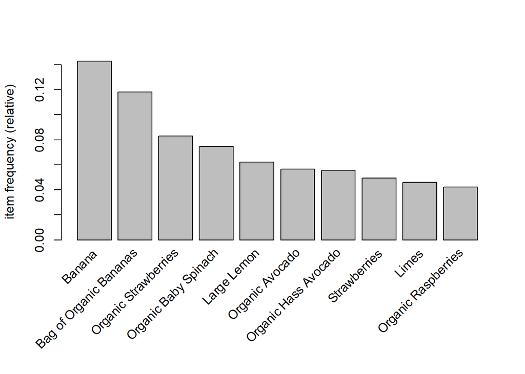

```r
itemFrequencyPlot(transacoes, topN = 10)
```

O resultado dessa transformação foi um elemento do tipo “transactions” com 131209 linhas (itemset) e 39123 colunas (items), sendo os itens mais frequentes: Banana, Bolsa de Bananas Orgânicas e Morangos Orgânicos.

ECLAT O algoritmo ECLAT lida apenas com o suporte, ou seja, leva em consideração apenas a frequência dos itens de acordo com as transações (pedidos, neste caso), sendo uma versão simplificada do algoritmo APRIORI.

```r
df_eclat %>%
    kbl() %>% kable_paper('striped',full_width = F) %>%
    row_spec(0, bold = T)
```

|  | items | support | transIdenticalToItemsets | count |
| --- | --- | --- | --- | --- |
| [1] | {Bag of Organic Bananas,Organic Strawberries} | 0.0234283 | 3074 | 3074 |
| [2] | {Bag of Organic Bananas,Organic Hass Avocado} | 0.0184439 | 2420 | 2420 |
| [3] | {Bag of Organic Bananas,Organic Baby Spinach} | 0.0170415 | 2236 | 2236 |
| [4] | {Banana,Organic Avocado} | 0.0168891 | 2216 | 2216 |
| [5] | {Banana,Organic Strawberries} | 0.0165690 | 2174 | 2174 |
| [6] | {Banana,Large Lemon} | 0.0164470 | 2158 | 2158 |
| [7] | {Banana,Organic Baby Spinach} | 0.0152429 | 2000 | 2000 |
| [8] | {Banana,Strawberries} | 0.0148465 | 1948 | 1948 |
| [9] | {Bag of Organic Bananas,Organic Raspberries} | 0.0135661 | 1780 | 1780 |
| [10] | {Organic Raspberries,Organic Strawberries} | 0.0127278 | 1670 | 1670 |

Observamos a presença do item banana (orgânica ou não) em quase todas as 10 primeiras regras. Isso significa que esse item é um dos mais badalados e o mercado deve sempre estar atento ao estoque e reposição nas gôndulas. Vale também observar os horários de pico de compras para que nunca falte este item para os consumidores.

APRIORI A diferença do APRIORI para o ECLAT é a inclusão do parâmetro de confiança e da elevação no cálculo, tornando este um algoritmo mais completo.

```r
df_apriori <- data.frame(
    lhs = labels(lhs(combinacoes_apriori)),
    rhs = labels(rhs(combinacoes_apriori)),
    combinacoes_apriori@quality)[1:10,]

df_apriori %>%
    kbl() %>% kable_paper('striped',full_width = F) %>%
    row_spec(0, bold = T)
```

| lhs | rhs | support | confidence | coverage | lift | count |
| --- | --- | --- | --- | --- | --- | --- |
| {Bartlett Pears} | {Banana} | 0.0035516 | 0.3860812 | 0.0091991 | 2.705187 | 466 |
| {Granny Smith Apples} | {Banana} | 0.0033077 | 0.3147208 | 0.0105099 | 2.205180 | 434 |
| {Yellow Bell Pepper} | {Orange Bell Pepper} | 0.0030181 | 0.3396226 | 0.0088866 | 23.906409 | 396 |
| {Unsweetened Original Almond Breeze Almond Milk} | {Banana} | 0.0033306 | 0.2982935 | 0.0111654 | 2.090078 | 437 |
| {Clementines, Bag} | {Banana} | 0.0035516 | 0.3152909 | 0.0112645 | 2.209175 | 466 |
| {Red Raspberries} | {Banana} | 0.0033458 | 0.2940388 | 0.0113788 | 2.060266 | 439 |
| {Grape White/Green Seedless} | {Banana} | 0.0030638 | 0.2632613 | 0.0116379 | 1.844615 | 402 |
| {Organic Broccoli} | {Bag of Organic Bananas} | 0.0040012 | 0.3176044 | 0.0125982 | 2.692025 | 525 |
| {Organic Grade A Free Range Large Brown Eggs} | {Bag of Organic Bananas} | 0.0033915 | 0.2518393 | 0.0134671 | 2.134598 | 445 |
| {Organic Black Beans} | {Bag of Organic Bananas} | 0.0031400 | 0.2614213 | 0.0120114 | 2.215816 | 412 |

lhs = left-hand side rhs = right-hand side Ou seja, no quadro vemos os itens que foram associados. Se analisarmos a primeira dupla, observamos que quando o consumidor compra Bartlett Pears, existe 38% de chances dele também levar Banana (confidence). Se analisarmos, porém, a terceira dupla deste dataset, observamos que quando se compra Yellow Bell Pepper, são 24 vezes mais propensos a comprar Orange Bell Pepper (lift = 23,91%).

**Conclusões Parte 1** De forma geral, frutas e verduras são os itens mais comprados e, geralmente, são comprados juntos. Cabe ao mercado organizar esses produtos nas gôndulas e corredores de uma maneira que facilite ao consumidor realizar suas compras. Aparentemente os compradores parecem ter gosto por cozinhar, comprando itens para o preparo das refeições. Também observamos bebidas leves e saudáveis como águas saborizadas. Aparentemente os usuários possuem hábitos de vida saudáveis.

### Parte 2

Análise Exploratória com fins de previsão de valores Fazendo previsões de acordo com o user_id ou order_id - quais os produtos que serão comprados juntos?

Join dos datasets e retiradas as colunas de dia da semana e hora da realização do pedido e número do pedido pois não agregam valor a esta parte do projeto:

```r
novo_df <- df_pedidos2 %>%
    select(-order_dow, -order_hour_of_day, -order_number) %>%
    left_join(pedidos_esp, by = c("order_id"))
```

**Feature Engineering**

Quantidade de produtos naquela compra

```r
novo_df <- novo_df %>%
    left_join(novo_df %>% group_by(order_id) %>% summarize(qtd_prod_por_pedido = n()),
              by = c ("order_id"))
```

Quantidade de vezes que o produto foi pedido

```r
novo_df <- novo_df %>%
    left_join(novo_df %>% group_by(product_id) %>% summarize(qtd_vezes_prod_pedido = n()),
              by = c("product_id"))
```

Quantidade de vezes que o produto foi pedido como 1 item do carrinho

```r
novo_df <- novo_df %>%
    left_join(novo_df %>% filter(add_to_cart_order == 1) %>% group_by(product_id) %>% summarize(prim_carrinho = n()),
              by = c("product_id"))
```

Quantidade de vezes que o produto foi reorded

```r
novo_df <- novo_df %>%
    left_join(novo_df %>% filter(reordered == 1) %>% group_by(product_id) %>% summarize(qtd_reorded = n()),
              by = c("product_id"))
```

Quantidade de pedidos feitos pelo usuário / Média total de pedidos

```r
novo_df <- novo_df %>%
    left_join(novo_df %>% group_by(user_id) %>% summarize(contagem = n())
              %>% mutate(media_ped_usu = round(contagem / mean(contagem),2)) %>% select(-contagem),
              by = c("user_id"))
```

**Substituindo valores NA**

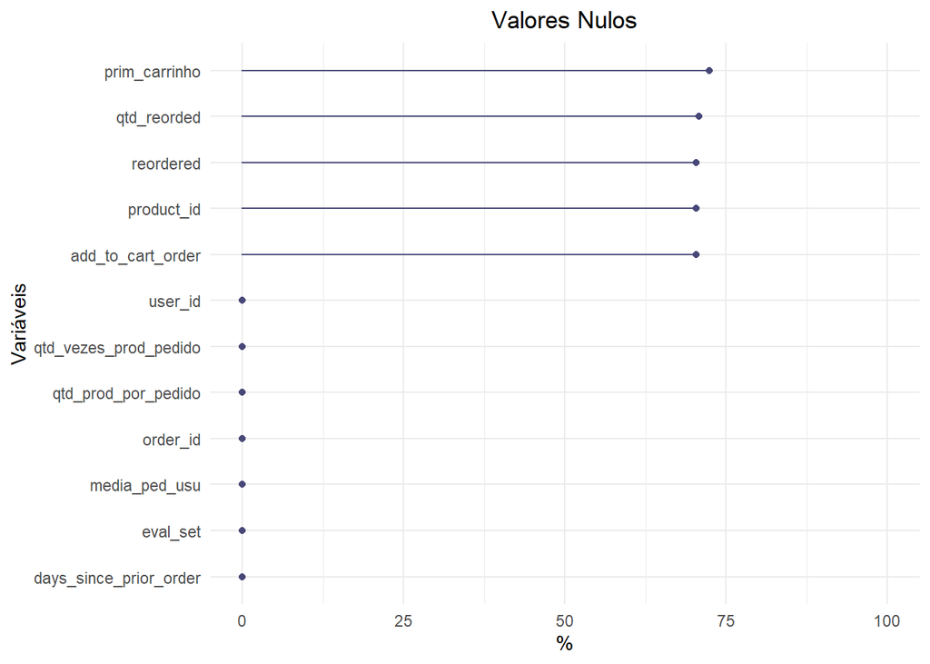

```r
gg_miss_var(novo_df, show_pct = TRUE) +
    labs(x = "Variáveis", y = "%", title = "Valores Nulos") +
    theme(plot.title = element_text(hjust = 0.5)) + ylim(0, 100)
```

As colunas prim_carrinho, qtd_reorded e add_to_cart_order serão preenchidas com zeros e as colunas reorded e product_id se manterão com NAs pois serão deletadas do dataset antes do início do treinamento do modelo.

```r
novo_df$prim_carrinho[is.na(novo_df$prim_carrinho)] <- 0
novo_df$qtd_reorded[is.na(novo_df$qtd_reorded)] <- 0
novo_df$add_to_cart_order[is.na(novo_df$add_to_cart_order)] <- 0
```

Conferindo se temos apenas reorded e product_id com valores nulos:

```r
df_nulo <- as.data.frame(sapply(novo_df, function(y) sum(length(which(is.na(y))))))
names(df_nulo) <- "Soma de Nulos"
df_nulo %>%
    kbl() %>% kable_paper('striped',full_width = F) %>%
    row_spec(0, bold = T)
```

|  | Soma de Nulos |
| --- | --- |
| order_id | 0 |
| user_id | 0 |
| eval_set | 0 |
| days_since_prior_order | 0 |
| product_id | 3289874 |
| add_to_cart_order | 0 |
| reordered | 3289874 |
| qtd_prod_por_pedido | 0 |
| qtd_vezes_prod_pedido | 0 |
| prim_carrinho | 0 |
| qtd_reorded | 0 |
| media_ped_usu | 0 |

**Treinamento e Avaliação do Modelo**

Divisão do dataset onde eval_set == ‘train’ entre treino e teste

```r
treino <- novo_df %>%
    filter(eval_set == "train") %>%
    select(-order_id, -eval_set)

divisao <- createDataPartition(treino$reordered, p = .8, list = FALSE)
df_treino <- treino[divisao,]
df_teste <- treino[-divisao,]
```

Aplicação do modelo no grupo de teste

```r
mat_teste <- xgb.DMatrix(as.matrix(df_teste %>% select(-reordered, -product_id, -user_id))
                         ,label = df_teste$reordered)

df_teste$previsoes <- predict(modelo, mat_teste)
```

Como o algoritimo xgboost nos entrega uma probabilidade, ou seja, se a previsão foi de 62%, isto significa que existe 62% de chances daquele produto ser pedido novamente, vamos aplicar um limiar (threshold) para selecionar apenas previsões >= 70%

```r
df_teste$previsoes <- ifelse(df_teste$previsoes >= .7, 1, 0)
```

Avaliação do modelo Para saber se o modelo foi bem sucedido, vou verificar se as previsoes acertaram se comparadas às verdadeiras classificações do dataset

```r
df_teste$sucesso <- ifelse(df_teste$reordered == df_teste$previsoes, "sim", "não")

df_teste %>%
    group_by(sucesso) %>%
    summarize(contagem = n()) %>%
    mutate(`% de acertos` = paste0(round(((contagem / sum(contagem)) * 100), 2), " %")) %>%
    kbl() %>% kable_paper('striped',full_width = F) %>%
    row_spec(0, bold = T)
```

| sucesso | contagem | % de acertos |
| --- | --- | --- |
| não | 95534 | 34.5 % |
| sim | 181389 | 65.5 % |

Nosso modelo acertou pouco mais 65% dos casos, não sendo muito satisfatório. Vamos tentar alcançar pelo menos 70% com um novo treinamento com mais rounds:

```r
df_teste$previsoes2 <- predict(novo_modelo, mat_teste)

df_teste$previsoes2 <- ifelse(df_teste$previsoes2 >= .7, 1, 0)
```

Agora, para avaliar o modelo, criaremos uma matriz de confusão A matriz de confusão é uma tabela de contingência de tamanho 2 x 2 que nos permite identificar quantas vezes o modelo acertou e quantas ele errou

```r
confusionMatrix(as.factor(df_teste$previsoes2), as.factor(df_teste$reordered))
```

```
## Confusion Matrix and Statistics
##
##           Reference
## Prediction     0     1
##          0 93794 77936
##          1 17198 87995
##
##                Accuracy : 0.6565
##                  95% CI : (0.6547, 0.6582)
##     No Information Rate : 0.5992
##     P-Value [Acc > NIR] : < 2.2e-16
##
##                   Kappa : 0.3442
##
##  Mcnemar's Test P-Value : < 2.2e-16
##
##             Sensitivity : 0.8451
##             Specificity : 0.5303
##          Pos Pred Value : 0.5462
##          Neg Pred Value : 0.8365
##              Prevalence : 0.4008
##          Detection Rate : 0.3387
##    Detection Prevalence : 0.6201
##       Balanced Accuracy : 0.6877
##
##        'Positive' Class : 0
##
```

Não obtivemos resultado muito diferente, a acurácia segue mais ou menos por volta de 65%. Na matriz de confusão observamos poucos falsos positivos - quantidade de vezes que o produto não foi pedido novamente mas o modelo previu que sim - mas altíssimos casos de falsos negativos - quantidade de vezes que o produto foi pedido novamente mas o modelo previu que não.

**Conclusões Parte 2**

Não obtive bons resultados com a aplicação do algoritmo xgboost. Cabe realização de mais estudos para aplicações de outros algoritmos ou, a realização de nova etapa de feature engineering ou, ainda, o ajuste de hiperparâmetros no algoritmo usado.

### Entrega do Resultado - quais produtos previstos para os usuários em seu próximo pedido?

Antes de entregar o resultado, vamos comparar os produtos que de fato foram comprados e os que nosso modelo previu

```r
previsoes <- df_teste %>%
    filter(previsoes2 == 1) %>%
    inner_join(produtos, by ="product_id") %>%
    group_by(user_id) %>%
    summarize(produtos_previstos = paste0(product_name, collapse = ", "))

produtos_reais <- df_teste %>%
    filter(reordered == 1) %>%
    inner_join(produtos, by ="product_id") %>%
    group_by(user_id) %>%
    summarize(produtos_reais = paste0(product_name, collapse = ", "))

comparando_produtos <- previsoes %>%
    inner_join(produtos_reais, by = "user_id")

comparando_produtos[1:10,] %>%
    rename("ID Usuário" = "user_id"
           ,"Produtos Previstos" = "produtos_previstos"
           ,"Produtos Reais" = "produtos_reais") %>%
    kbl() %>% kable_paper('striped',full_width = F) %>%
    row_spec(0, bold = T)
```

| ID Usuário | Produtos Previstos | Produtos Reais |
| --- | --- | --- |
| 2 | Bartlett Pears, Organic D’Anjou Pears, Unsweetened Almondmilk | Bartlett Pears, Organic D’Anjou Pears, Pad Thai |
| 7 | Panama Peach Antioxidant Infusion, Lactose Free Fat Free Milk | Lactose Free Fat Free Milk |
| 9 | Caffeine Free Diet Cola All Natural Soda, Raspberry Lime Sparkling Seltzer Water | Caffeine Free Diet Cola All Natural Soda, Raspberry Lime Sparkling Seltzer Water, Spicy Hummus, Organic American Cheese Singles, Goo Berry Pie Probugs Kefir, Honey Nut Cheerios |
| 14 | 93/7 Ground Beef | 93/7 Ground Beef, Sweet Hot Dog Buns, Coconut Oil Cooking Spray |
| 27 | Red Raspberries, Total 2% with Strawberry Lowfat Greek Strained Yogurt, Total 2% Lowfat Greek Strained Yogurt with Peach, Organic Raspberry Lowfat Yogurt, Yogurt, Lowfat, Strawberry | Total 2% with Strawberry Lowfat Greek Strained Yogurt, Total 2% Lowfat Greek Strained Yogurt with Peach, Yogurt, Lowfat, Strawberry |
| 29 | Cran-Apple Juice Drink, Bars Peanut Butter | Extra Soft Double Roll Bathroom Tissue, Cran-Apple Juice Drink, Bars Peanut Butter, Eagle Brand Sweetened Condensed Milk, Pure Life Purified Water |
| 38 | Shredded Parmesan, Organic Hass Avocado | Shredded Parmesan, Sustainably Soft Bath Tissue, Organic Hass Avocado |
| 43 | Natural Sharp Cheddar Sliced Cheese | Red Raspberries, Traditional Favorites Tomato & Basil Pasta Sauce |
| 48 | Super Seed Crispy Crackers, Organic Zucchini | Organic Zucchini, Parmesan Couscous Mix |
| 50 | Bag of Organic Bananas, Organic Baby Spinach | Bag of Organic Bananas, Organic Baby Spinach |

Salvando o Resultando

```r
sub <- df_teste %>%
    filter(previsoes2 == 1) %>%
    group_by(user_id) %>%
    summarize(produtos = paste0(product_id, collapse = " "))

write.csv(sub, file = "datasets/resultado_final.csv", row.names = F, quote = F)
```

### Referências Bibliográficas

- “The Instacart Online Grocery Shopping Dataset 2017”, accessed from https://www.instacart.com/datasets/grocery-shopping-2017 on 2022-01-09
- Formação Cientista de Dados - Data Science Academy